# Midterm

Vinayak Mathur

3/1/22

## Problem 1

Because not all airline passengers show up for their reserved seats, an airline sells 54 tickets for a flight that holds 50 passengers. The probability that a passenger does not show up is 0.05 and the passengers behave independently.  
1. What is the probability that every passenger who shows up gets a seat? (8 points)  
2. What is the probability that the flight departs with at least one empty seat? (8 points)

```r
# 4 must not show up out of 54 with a probability of 0.05. We use the dbinom function to find the value.
dbinom(4,54, 0.05)
```

```
## [1] 0.152087
```

```r
# at least 5 people must not show up.
1-dbinom(4,54, 0.05)
```

```
## [1] 0.847913
```

## Problem 2

An inexpensive blood test can be used to test whether or not a person has a certain type of disease. The test is not perfect: there is an 8% chance that a person who has the disease will falsely test negative and a 5% chance that a person who does not have the disease will falsely test positive. More accurate (and more expensive) testing has shown that the disease is present in 10% of the tested population.  
1. Given that a person tests negative what is the probability he/she does not have this type of disease? (8 points)  
2. Given that a person tests positive what is the probability he/she actually has this type of disease? (8 points)  
Let A be the event of getting a positive.  
P(A) = 0.1  
Let B be the event of getting a negative.  
P(A) = 0.9  
Let C be the event of getting a wrong result.  
1.P(B^C’) = P(B) * P(C’)  
0.92  
2.P(A^C’) = P(A) * P(C’)  
0.95

## Problem 3

At a large university students have either a final exam or a final paper at the end of a course. Let X be the random variable denoting the number of final exams that students at the university will take. The table below lists the probability mass function of X.  
x 0 1 2 3 4  
P(X=x) 0.1 ? 0.3 0.2 0.2  
1. The probability P(X=1) is missing. What is the value of P(X = 1)? (8 points)  
2. Write down the cumulative distribution function of X and plot it. A rough sketch is fine. You can also use R to plot it (optional) (10 points)  
3. Find the mean of this distribution. (8 points)

$$\sum_{x=0}^{n} P(X=x) = 1$$
so
$$P(X=1) = 1 - \sum_{x=0, x\neq 1}^{n}
P(X=x)$$
$$ans = 1 - (0.1 + 0.3 + 0.2
+ 0.2)$$
$$ans = 0.2$$

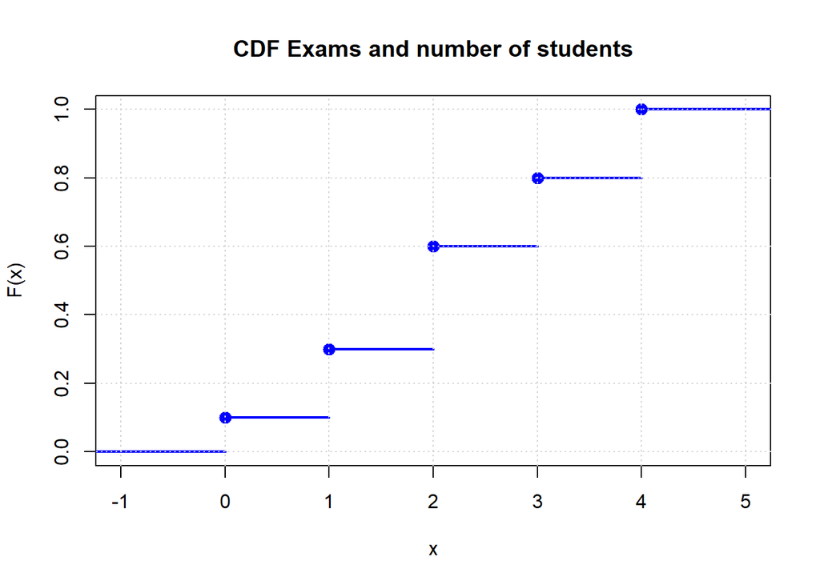

```r
exams <- c(0, 1, 2, 3, 4)
proportions <- c(0, 0.1, 0.2, 0.3, 0.2, 0.2)

plot(stepfun(exams, cumsum(proportions)), vertical = F, pch = 20, cex = 2, lwd = 2, col = "blue", ylab = "F(x)",
     main = "CDF Exams and number of students")
grid()
```

```r
proportions <- c(0.1, 0.2, 0.3, 0.2, 0.2)
sum(proportions*exams)
```

```
## [1] 2.2
```